# STATS 32: Introduction to R for Undergraduates

Elena Tuzhilina

Oct 19, 2021  
http://web.stanford.edu/~elenatuz/courses/stats32-aut2021/

# Reminder!

The project proposal is due Oct 20 (Wed) 11:59pm.

# Recap of week 4

- Importing data with `readr`
- Where does your data live?
- Factors
- Markdown and R markdown

# Agenda for today

- Making maps in R
- Joining datasets

# Making maps in R: `maps` package

- `maps` package contains a lot of outlines of continents, countries, states, and counties
- `ggplot2`’s `map_data()` function puts these outlines in data frame format, which then allows us to plot them with `ggplot()`

# Example: Drawing CA and its counties (1)

```r
library(tidyverse)
library(maps)
```

```r
county_data <- map_data("county")
CA_data <- county_data %>% filter(region == "california")
head(CA_data)
```

```
##        long      lat group order     region subregion
## 1 -121.4785 37.48290   157  6965 california   alameda
## 2 -121.5129 37.48290   157  6966 california   alameda
## 3 -121.8853 37.48290   157  6967 california   alameda
## 4 -121.8968 37.46571   157  6968 california   alameda
## 5 -121.9254 37.45998   157  6969 california   alameda
## 6 -121.9483 37.47717   157  6970 california   alameda
```

# Example: Drawing CA and its counties (2)

County outlines are drawn using `geom_polygon`.

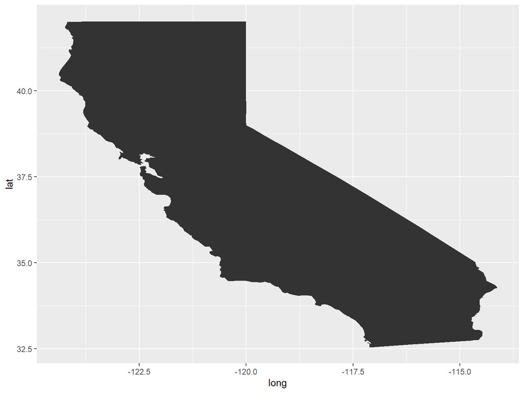

```r
ggplot(data = CA_data) +
    geom_polygon(mapping = aes(x = long, y = lat, group = group))
```

# Example: Drawing CA and its counties (3)

`coord_quickmap()` preserves the aspect ratio of the map.

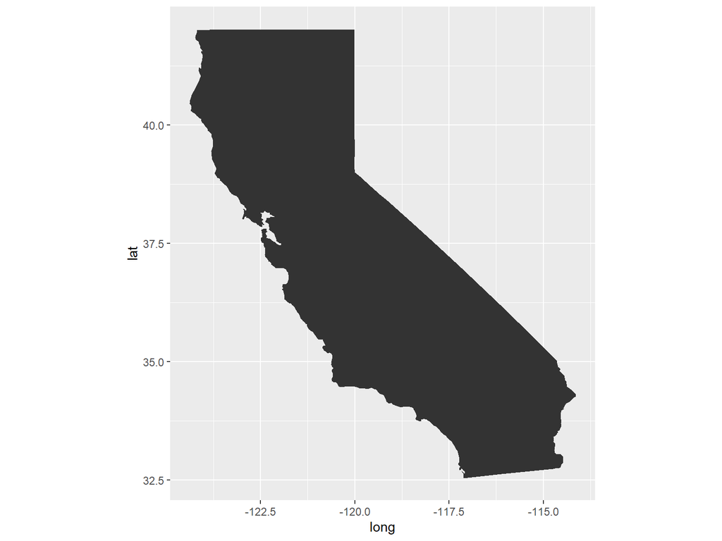

```r
ggplot(data = CA_data) +
    geom_polygon(mapping = aes(x = long, y = lat, group = group)) +
    coord_quickmap()
```

# Example: Drought levels in CA (1)

```r
drought_data <- read_csv("Drought data.csv")
head(drought_data, n = 3)
```

```
## # A tibble: 3 x 2
##   County  Drought_percent
##   <chr>             <dbl>
## 1 alameda             100
## 2 alpine              100
## 3 amador              100
```

```r
head(CA_data, n = 3)
```

```
##        long     lat group order     region subregion
## 1 -121.4785 37.4829   157  6965 california   alameda
## 2 -121.5129 37.4829   157  6966 california   alameda
## 3 -121.8853 37.4829   157  6967 california   alameda
```

Our drought data and mapping information are in different datasets!

# Joining datasets

Sometimes our data are spread across different datasets, making it difficult to answer some questions.

**Question:** Who scored the highest in English in each class?

```r
bio
```

```
##     Name Class
## 1 Andrew     A
## 2   John     B
## 3   Mary     A
## 4   Jane     B
```

```r
scores
```

```
##     Name Subject Score
## 1   John English    76
## 2 Andrew English    66
## 3   John    Math    85
## 4   Mary English    71
```

# Joining datasets (using `dplyr`)

```r
library(dplyr)
left_join(bio, scores, by = "Name")
```

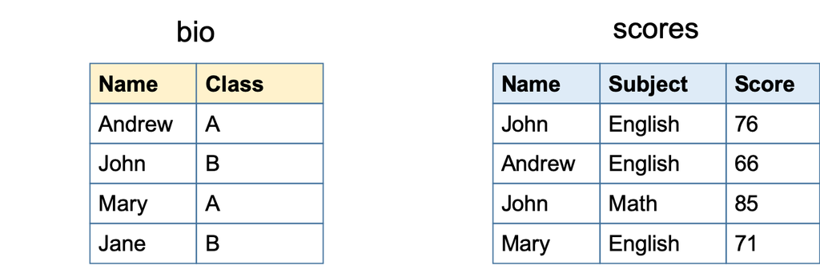

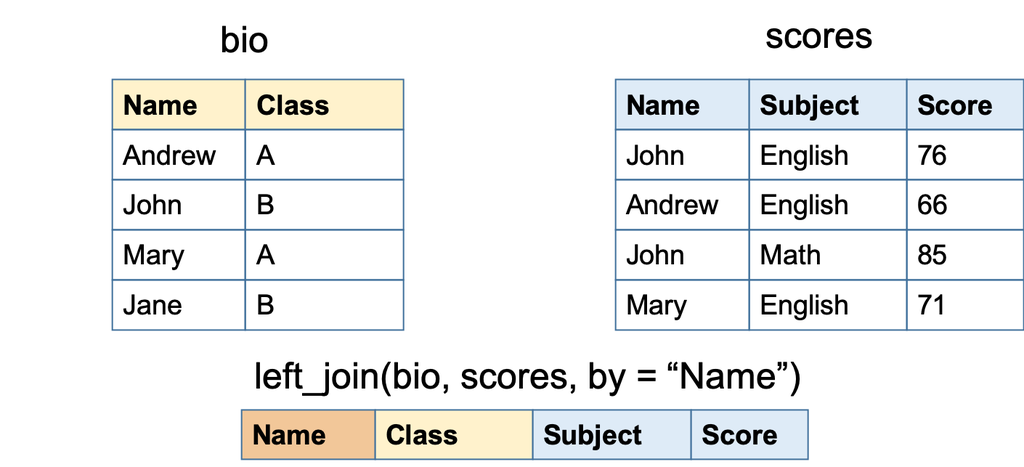

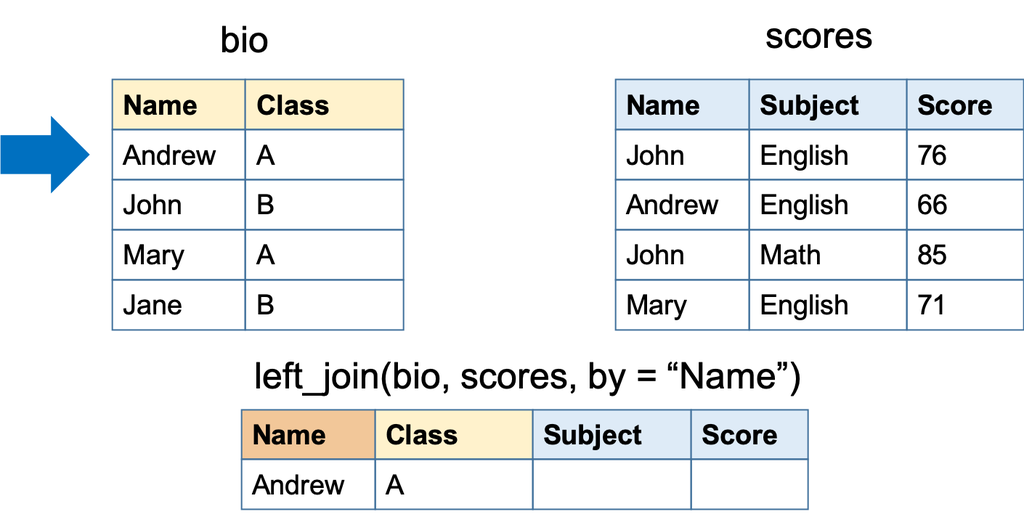

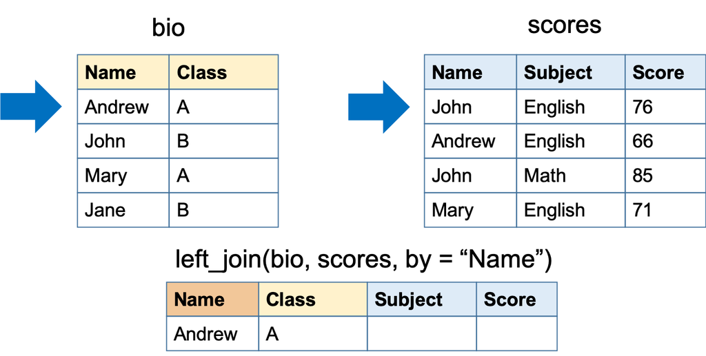

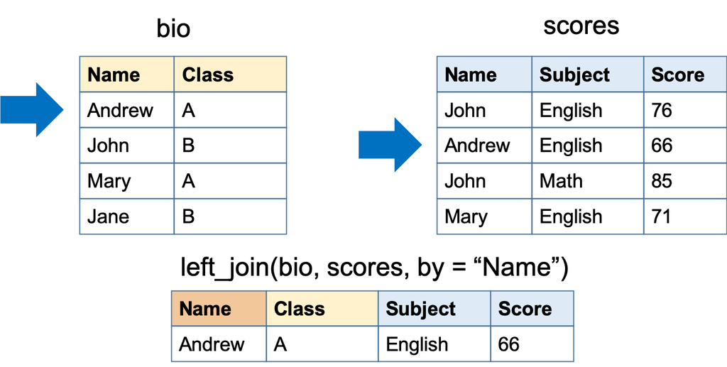

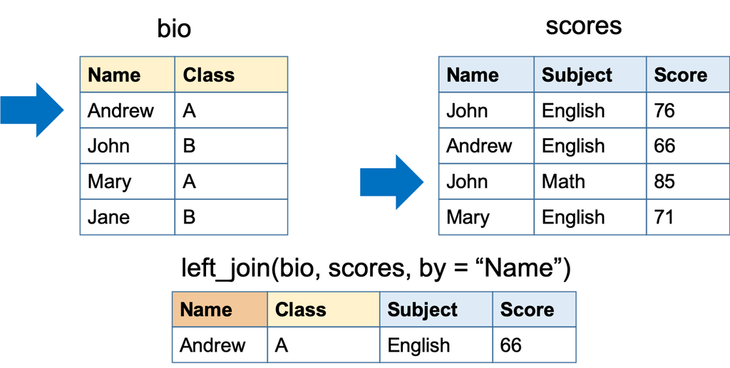

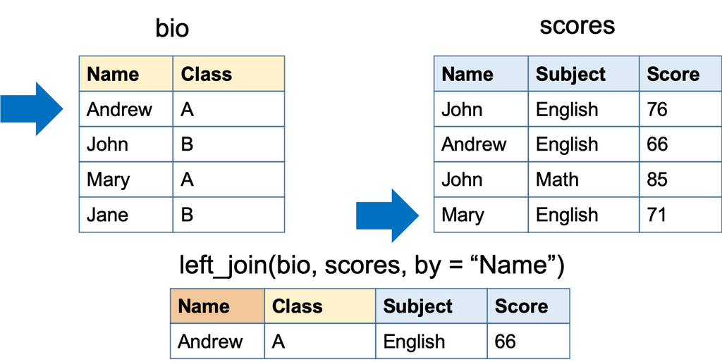

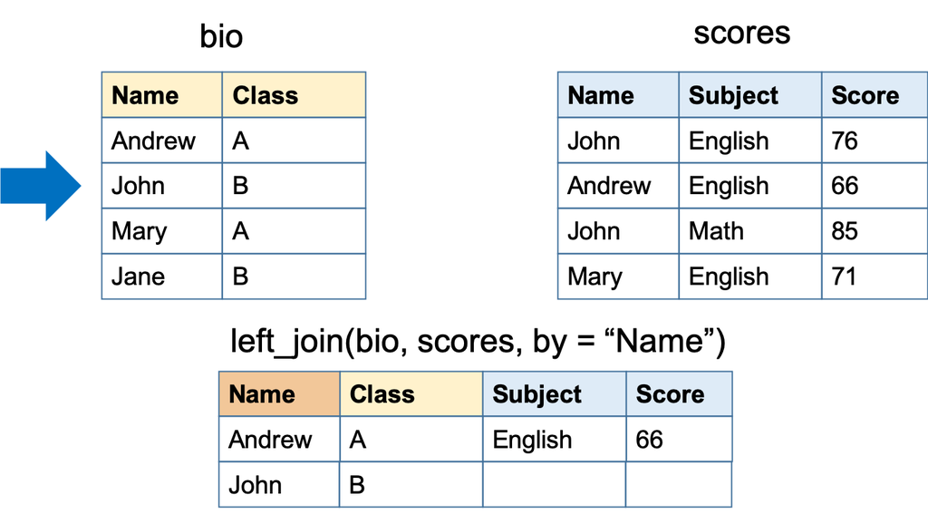

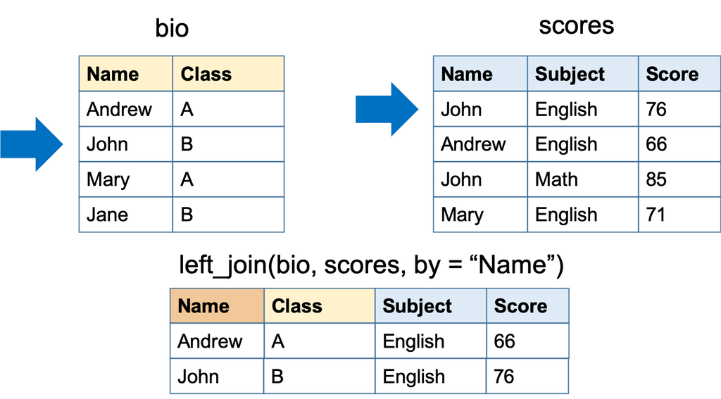

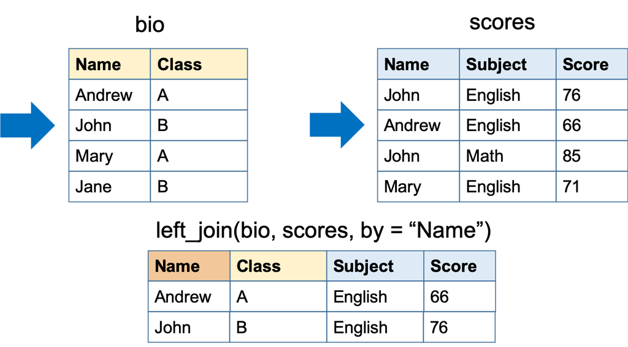

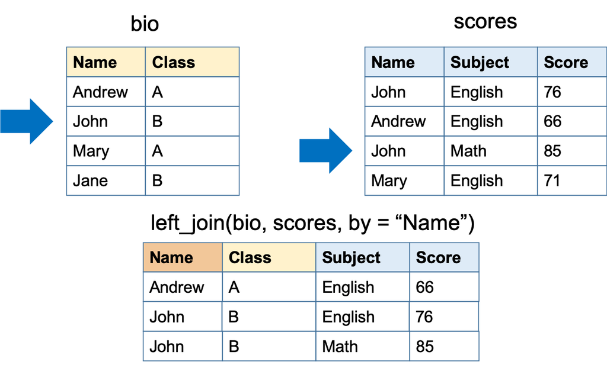

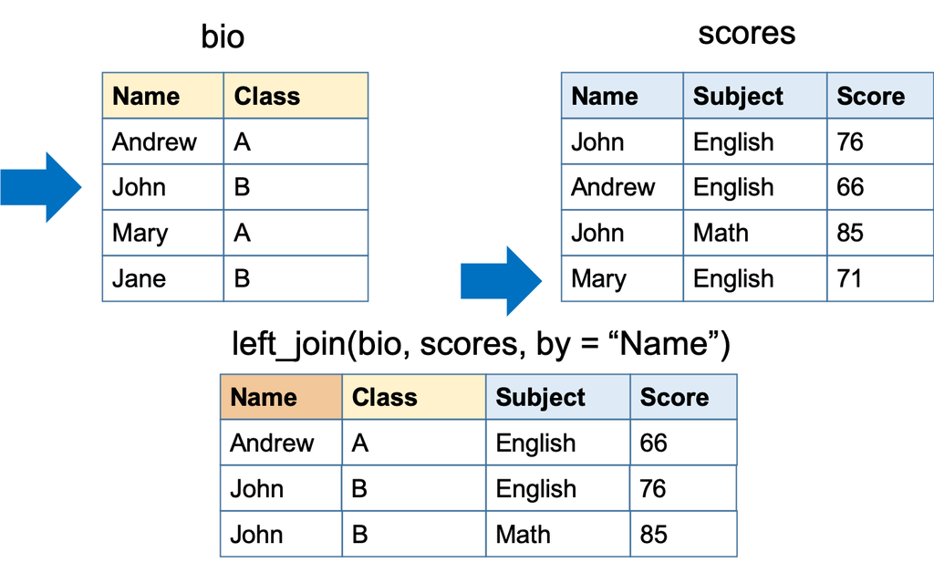

[9 more figures not shown]

# Joining datasets (using `dplyr`)

```r
library(dplyr)
left_join(bio, scores, by = "Name")
```

```
##     Name Class Subject Score
## 1 Andrew     A English    66
## 2   John     B English    76
## 3   John     B    Math    85
## 4   Mary     A English    71
## 5   Jane     B    <NA>    NA
```

# Joining datasets (using `dplyr`)

**Question:** Who scored the highest in English in each class?

```r
library(dplyr)
bio %>% left_join(scores, by = "Name") %>%
    filter(Subject == "English") %>%
    group_by(Class) %>%
    top_n(1, Score)
```

```
## # A tibble: 2 x 4
## # Groups:   Class [2]
##   Name  Class Subject Score
##   <chr> <chr> <chr>   <dbl>
## 1 John  B     English    76
## 2 Mary  A     English    71
```

# Example: Drought levels in CA (1)

```r
drought_data <- read_csv("Drought data.csv")
head(drought_data, n = 3)
```

```
## # A tibble: 3 x 2
##   County  Drought_percent
##   <chr>             <dbl>
## 1 alameda             100
## 2 alpine              100
## 3 amador              100
```

```r
head(CA_data, n = 3)
```

```
##        long     lat group order     region subregion
## 1 -121.4785 37.4829   157  6965 california   alameda
## 2 -121.5129 37.4829   157  6966 california   alameda
## 3 -121.8853 37.4829   157  6967 california   alameda
```

Our drought data and mapping information are in different datasets!

# Example: Drought levels in CA (2)

Solution: **Join** the datasets together.

```r
combined_data <- CA_data %>%
    left_join(drought_data, by = c("subregion" = "County"))
head(combined_data)
```

```
##        long      lat group order     region subregion Drought_percent
## 1 -121.4785 37.48290   157  6965 california   alameda             100
## 2 -121.5129 37.48290   157  6966 california   alameda             100
## 3 -121.8853 37.48290   157  6967 california   alameda             100
## 4 -121.8968 37.46571   157  6968 california   alameda             100
## 5 -121.9254 37.45998   157  6969 california   alameda             100
## 6 -121.9483 37.47717   157  6970 california   alameda             100
```

# Example: Drought levels in CA (3)

Map the `fill` attribute of `geom_polygon` to the `Drought_percent` column.

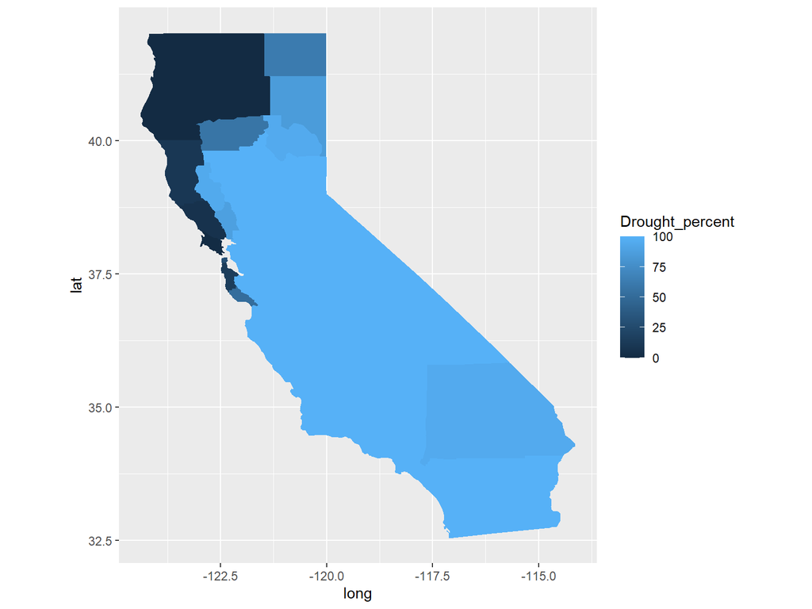

```r
ggplot(data = combined_data) +
    geom_polygon(mapping = aes(x = long, y = lat,
            group = group, fill = Drought_percent)) +
    coord_quickmap()
```

# Example: Drought levels in CA (4)

Use `scale_fill_distiller` to define a more appropriate color scale.

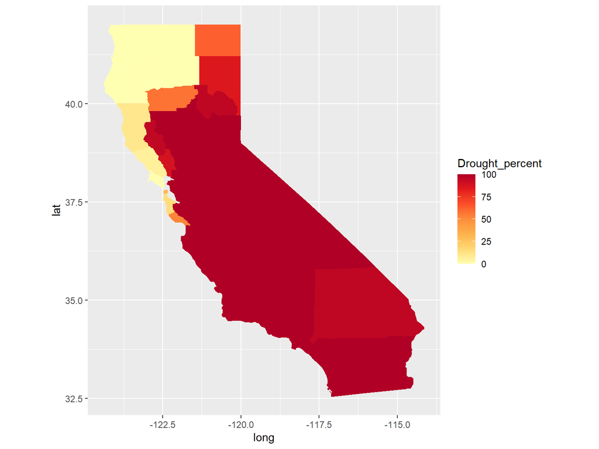

```r
ggplot(data = combined_data) +
    geom_polygon(mapping = aes(x = long, y = lat,
            group = group, fill = Drought_percent)) +
    scale_fill_distiller(palette = "YlOrRd", direction = 1) +
    coord_quickmap()
```

# Today’s dataset: 2016 US Presidential Elections

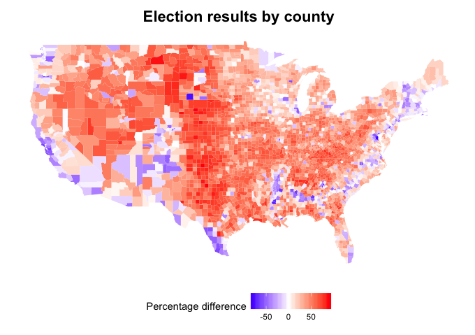

**Optional material**

# Other types of joins

*Inner join*: Matches pairs of observations with equal keys, drops everything else. Hence, only keeps observations which appear in both datasets.

# Other types of joins

After matching pairs of observations with equal keys…

- *Left join*: Keeps all observations in the left dataset, drops everything unmatched in the right dataset.
- *Right join*: Keeps all observations in the right dataset, drops everything unmatched in the left dataset.
- *Full join*: Keeps all observations in both datasets.